# Generalised Linear Models, 2: Transformed linear and multiple linear regression

Dr. Eugenie Hunsicker

Copyright Loughborough University, 2021 Last update: 16 November

# Preamble

## Read in packages

```r
library("tidyverse")
library("magrittr")
library("here")
library("janitor")
library("readxl")
library("lindia")
```

## Read in data

```r
trees2 <- trees %>%
  mutate(Diameter = Girth) %>%
  select(Height,Diameter,Volume)
```

```r
autot<-clean_names(read_csv(here("data", "Automobile_data.csv"),
                            na = c("?","","NA","N/A","Na"),))  #this ensures that missing data recorded in a variety of ways is identified as missing data by R
```

# Section 3: Multiple regression and derived variables

So far we have considered a situation in which we were interested in predicting a response from a single predictor. But more generally, there are many different variables that can and will affect a response of interest. When we build a model that involves several predictors, this is called *multiple regression*.

## 3.1 Choosing and fitting a first model

Going back to the trees dataset, we can look at the relationship of both height and diameter to volume.

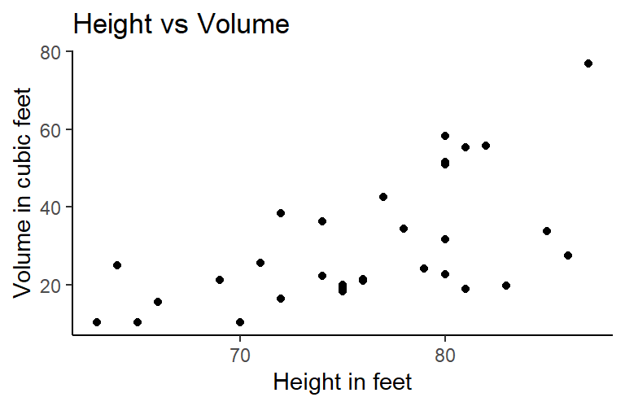

```r
trees2 %>% ggplot(aes(Height,Volume))+
  geom_point() +
  labs(x = "Height in feet", y = "Volume in cubic feet") +
  ggtitle("Height vs Volume") +
  theme_classic()
```

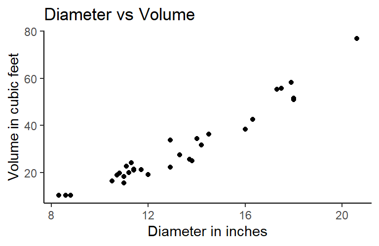

```r
trees2 %>% ggplot(aes(Diameter,Volume))+
  geom_point() +
  labs(x = "Diameter in inches", y = "Volume in cubic feet") +
  ggtitle("Diameter vs Volume") +
  theme_classic()
```

Again, we see a roughly linear trend upwards in both of these plots, so we can assume initially that a linear model is reasonable:

$$mean({\rm Volume}) = b_0 + b_1\times {\rm Height} + b_2\times {\rm Diameter}.$$

Note that we have the same type of equation as before, but we have added a third term. The model we will fit is of the form:
$${\rm Volume} \sim N(b_0 + b_1\times {\rm Height} + b_2\times {\rm Diameter},\sigma),$$

where as before, $\sigma$ is a hidden parameter that relates to the width of spread of points around the predicted values.

In R it is quite simple to fit this model:

```r
linmod2<-lm(Volume~Height + Diameter,data=trees2)
summary(linmod2)
```

```
Call:
lm(formula = Volume ~ Height + Diameter, data = trees2)

Residuals:
    Min      1Q  Median      3Q     Max
-6.4065 -2.6493 -0.2876  2.2003  8.4847

Coefficients:
            Estimate Std. Error t value Pr(>|t|)
(Intercept) -57.9877     8.6382  -6.713 2.75e-07 ***
Height        0.3393     0.1302   2.607   0.0145 *
Diameter      4.7082     0.2643  17.816  < 2e-16 ***
---
Signif. codes:  0 '***' 0.001 '**' 0.01 '*' 0.05 '.' 0.1 ' ' 1

Residual standard error: 3.882 on 28 degrees of freedom
Multiple R-squared:  0.948, Adjusted R-squared:  0.9442
F-statistic:   255 on 2 and 28 DF,  p-value: < 2.2e-16
```

Now instead of two coefficients, we have three. We also have an estimate of the dispersion parameter. So the fitted model is

$${\rm Volume} \sim N(-57.9877 + 0.3393\times {\rm Height} + 4.7082\times {\rm Diameter},3.881832)$$

See if you can figure out where this came from.

## 3.2 Model transformation

We can examine the suitability by looking at residuals again as before. First examine the plots of residuals against each predictor to make sure the spread looks even and regular across the plot.

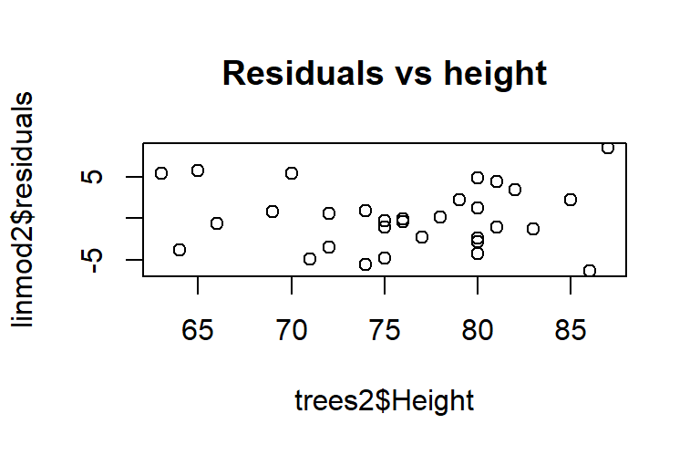

```r
plot(trees2$Height,linmod2$residuals,main="Residuals vs height")
```

This looks fine.

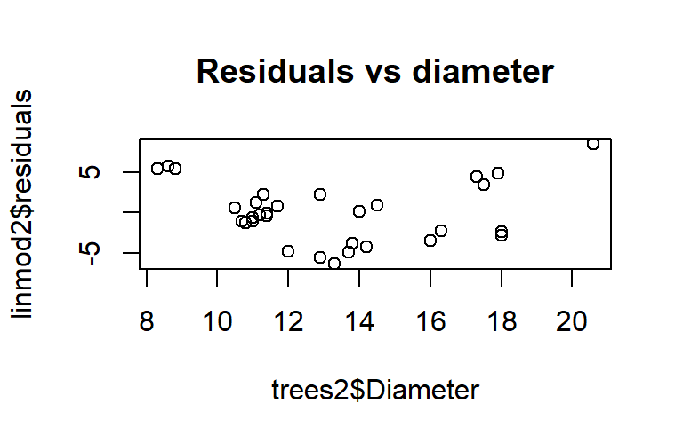

```r
plot(trees2$Diameter,linmod2$residuals,main="Residuals vs diameter")
```

Hmmm… this doesn’t look even. There is a distinct U-shaped trend. This suggests that maybe our model wasn’t right. In fact, if we think about this, it makes sense. From geometry, we would expect volume of a tree to scale like the *square* of its diameter, not its diameter, since

$$\begin{align}
\mbox{Volume of a cylinder} &= {\rm Height}\times {\rm area} \\
&= {\rm Height} \times \pi \times r^2 \\
&= {\rm Height} \times \pi \times {\rm Diameter}^2/4.
\end{align}$$

That is not a linear relationship!

When we come across a situation in which the relationship we want to model is not linear, there are various approaches to do this. One approach is to transform the variables somehow so that the transformed variables are linearly related, then model the relationship between the transformed variables instead. In this example, we will transform using logarithms. Recall that logarithms turn products into sums and powers into multiples. So if we take the log of both sides of the equation above, we get:

$$\log(\mbox{Volume of cylinder}) =\log(\pi/4)+ \log({\rm Height}) + 2 \times \log({\rm Diameter})$$

Trees are not exact cylinders, so instead we will assume a model of the form

$$\log({\rm Volume}) = b_0 +b_1\times \log({\rm Height}) + b_2\times \log({\rm Diameter}).$$

So we first add new variables to our datset. These are called *derived variables* because instead of being the originally measured variables, they are new variables calculated from these.

```r
trees2<- trees2 %>%
  mutate(logheight = log(Height)) %>%
  mutate(logvol = log(Volume)) %>%
  mutate(logdiam = log(Diameter))
```

Now let’s examine the scatters of these variables:

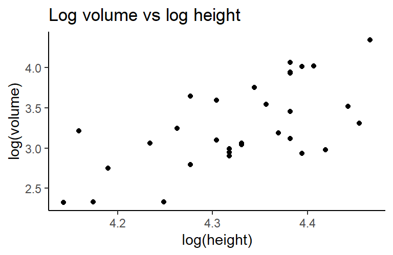

```r
trees2 %>% ggplot(aes(logheight,logvol))+
  geom_point()+
  labs(x = "log(height)", y = "log(volume)") +
  ggtitle("Log volume vs log height") +
  theme_classic()
```

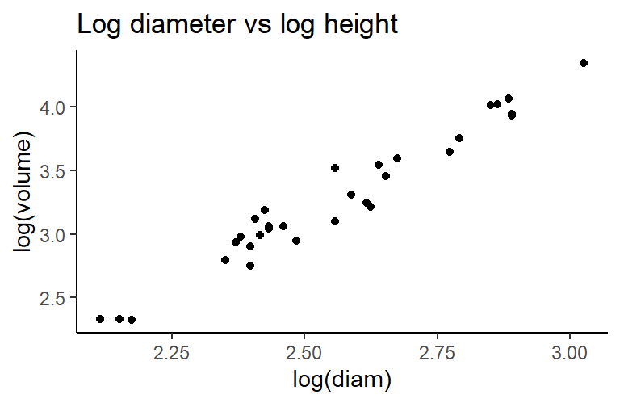

```r
trees2 %>% ggplot(aes(logdiam,logvol))+
  geom_point()+
  labs(x = "log(diam)", y = "log(volume)") +
  ggtitle("Log diameter vs log height") +
  theme_classic()
```

Now we fit the model

```r
linmod3<-lm(logvol~logheight + logdiam,data=trees2)
summary(linmod3)
```

```
Call:
lm(formula = logvol ~ logheight + logdiam, data = trees2)

Residuals:
      Min        1Q    Median        3Q       Max
-0.168561 -0.048488  0.002431  0.063637  0.129223

Coefficients:
            Estimate Std. Error t value Pr(>|t|)
(Intercept) -6.63162    0.79979  -8.292 5.06e-09 ***
logheight    1.11712    0.20444   5.464 7.81e-06 ***
logdiam      1.98265    0.07501  26.432  < 2e-16 ***
---
Signif. codes:  0 '***' 0.001 '**' 0.01 '*' 0.05 '.' 0.1 ' ' 1

Residual standard error: 0.08139 on 28 degrees of freedom
Multiple R-squared:  0.9777,    Adjusted R-squared:  0.9761
F-statistic: 613.2 on 2 and 28 DF,  p-value: < 2.2e-16
```

Now let’s have a look at the diagnostic plots.

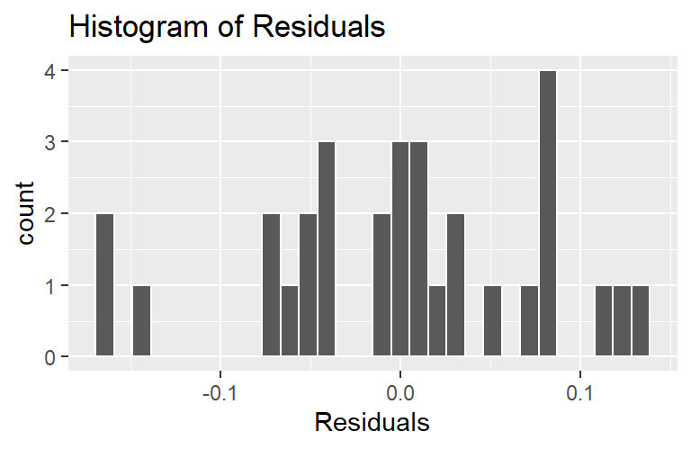

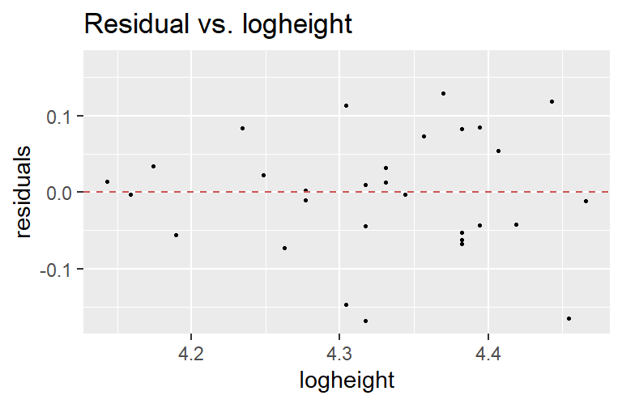

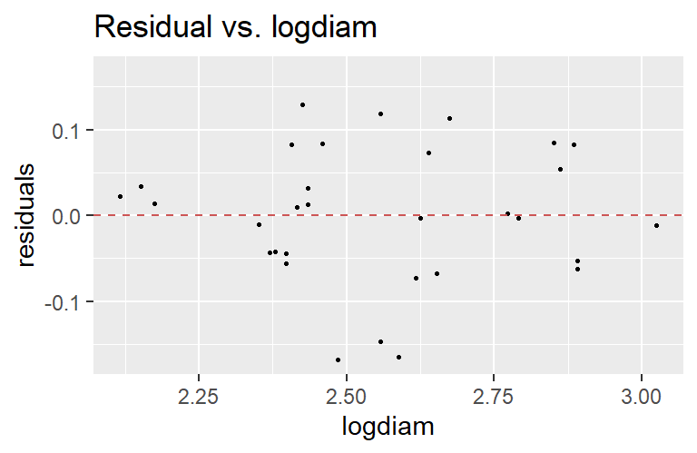

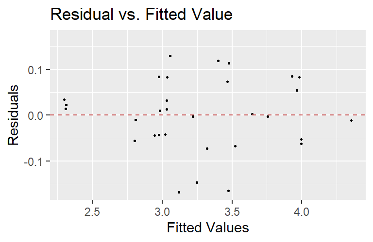

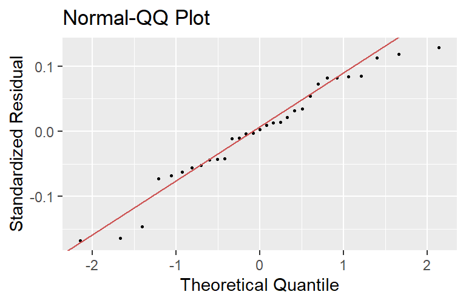

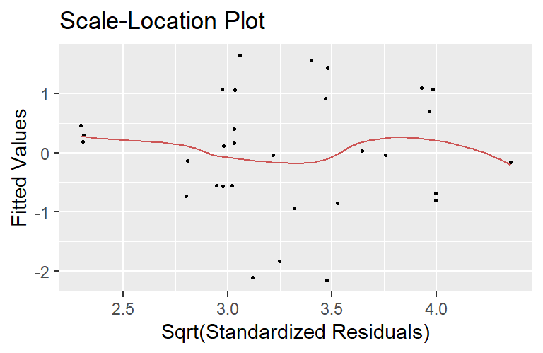

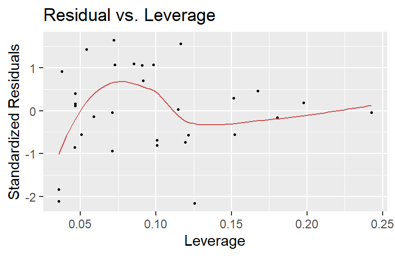

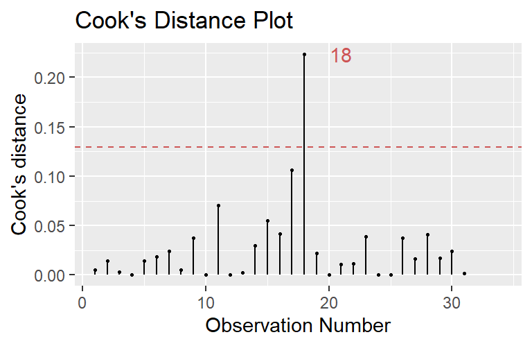

```r
linmod3 %>%
  gg_diagnose(max.per.page = 1)
```

Now look at the qq plot for residuals. Again, except a few points on the left, this looks pretty good.

So now we can write our final model, which will be in terms of the derived variables rather than the original variables:

$${\rm logvol} \sim N(-6.63162 + 1.11712\times {\rm logheight} + 1.98265\times {\rm logdiam}, 0.08138607).$$

## 3.3 Prediction in our model

```r
predict(linmod3,newdata=data.frame(logheight=log(80),logdiam=log(10)))
```

```
       1
2.828867
```

This seems a bit low, right? That is because what we have predicted isn’t the volume, but rather $\log({\rm volume})$. Recall that the $\exp$ function “undoes” $\log$. So to get back to volume, we do this:

```r
exp(predict(linmod3,newdata=data.frame(logheight=log(80),logdiam=log(10))))
```

```
       1
16.92628
```

# Section 4: Multiple regression with factors for the Gaussian family

So far we have only considered quantitative variables: height, diameter, volume. But in many datasets, some of the predictors of interest, or that may be confounders, are categorical: brand, country, species. When we use a categorical variable as a predictor, we call it a *factor*. To consider multiple regression when there are factors as well as continuous predictors (also sometimes called *covariates*), we will look at a dataset from the Ward’s Automotive Yearbook of 1985, available for download at [Kaggle](https://www.kaggle.com/toramky/automobile-dataset/data). We have already loaded this data in the preamble.

Let’s take a look at it

```r
autot
```

```
# A tibble: 205 x 26
   symboling normalized_loss~ make  fuel_type aspiration num_of_doors body_style
       <dbl>            <dbl> <chr> <chr>     <chr>      <chr>        <chr>
 1         3               NA alfa~ gas       std        two          convertib~
 2         3               NA alfa~ gas       std        two          convertib~
 3         1               NA alfa~ gas       std        two          hatchback
 4         2              164 audi  gas       std        four         sedan
 5         2              164 audi  gas       std        four         sedan
 6         2               NA audi  gas       std        two          sedan
 7         1              158 audi  gas       std        four         sedan
 8         1               NA audi  gas       std        four         wagon
 9         1              158 audi  gas       turbo      four         sedan
10         0               NA audi  gas       turbo      two          hatchback
# ... with 195 more rows, and 19 more variables: drive_wheels <chr>,
#   engine_location <chr>, wheel_base <dbl>, length <dbl>, width <dbl>,
#   height <dbl>, curb_weight <dbl>, engine_type <chr>, num_of_cylinders <chr>,
#   engine_size <dbl>, fuel_system <chr>, bore <dbl>, stroke <dbl>,
#   compression_ratio <dbl>, horsepower <dbl>, peak_rpm <dbl>, city_mpg <dbl>,
#   highway_mpg <dbl>, price <dbl>
```

Note this dataset has several categorical variables, such as make, fuel type, aspiration, body style and so on, as well as some quantitative variables, such as wheel base, length, width, height and so on. Something like number of doors, which only seems to take on two different values, 2 and 4, could be treated as either categorical or numerical.

Let’s look where there are missing values:

```r
autot %>% sapply(function(x) sum(is.na(x)) )
```

```
        symboling normalized_losses              make         fuel_type
                0                41                 0                 0
       aspiration      num_of_doors        body_style      drive_wheels
                0                 2                 0                 0
  engine_location        wheel_base            length             width
                0                 0                 0                 0
           height       curb_weight       engine_type  num_of_cylinders
                0                 0                 0                 0
      engine_size       fuel_system              bore            stroke
                0                 0                 4                 4
compression_ratio        horsepower          peak_rpm          city_mpg
                0                 2                 2                 0
      highway_mpg             price
                0                 4
```

In order to avoid dealing with missing values at the moment, let’s look at the relationship among variables without missing values, such as ‘fuel_type’, ‘body_style’, ‘width’, and ‘curb_weight’, and how those influence ‘highway_mpg’.

```r
autot <- autot %>%
  mutate_at(vars(fuel_type, body_style),
            list(factor))
```

You can notice that under the Environment tab at the top right of the RStudio window, if you look at the dataset autot by clicking the arrow to its left, that fuel is a factor with two levels, “diesel” and “gas”, and body is a factor with five levels, “convertible”, “hardtop”, “hatchback”, “sedan” and “wagon”.

## 4.1 Choosing a model with factors

Let’s look at the relationships between these covariates and the reponse, highway mpg:

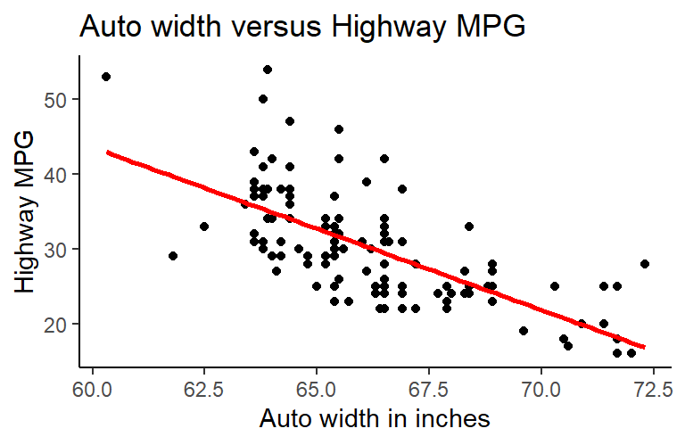

```r
autot %>%  ggplot(aes(width,highway_mpg))+
  geom_point()+
  geom_smooth(method = "lm", se = FALSE,colour="red") +
      labs(x = "Auto width in inches", y = "Highway MPG") +
      ggtitle("Auto width versus Highway MPG") +
      theme_classic()
```

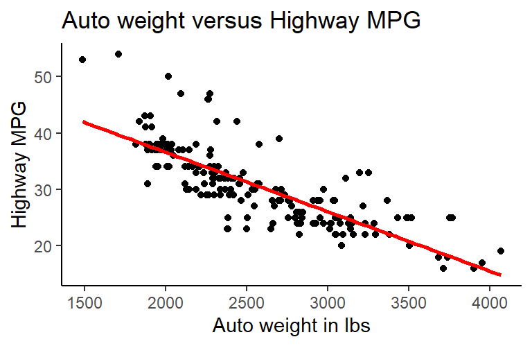

```r
autot %>%  ggplot(aes(curb_weight,highway_mpg))+
  geom_point()+
  geom_smooth(method = "lm", se = FALSE,colour="red") +
      labs(x = "Auto weight in lbs", y = "Highway MPG") +
      ggtitle("Auto weight versus Highway MPG") +
      theme_classic()
```

The two plots against covariates look relatively linear, so we can propose a linear model, at least to start. Note that we can ALWAYS propose a linear model for factors (categorical predictors). We will have to examine normality and homoscedasticity of residuals for both factors and covariates, though.

The model we will fit is of the form

$$\begin{align}
\mbox{mean highway mpg} &\sim N(b_0 + b_1\times {\rm width} + b_2\times {\rm curb-weight} \\
&+ b_3\times {\rm isgas} + b_4\times {\rm ishardtop} + b_5\times {\rm ishatchback}\\ &+ b_6\times {\rm issedan} + b_7\times {\rm iswagon}, \sigma).
\end{align}$$

Here ${\rm isgas} = 0$ if the fuel is not gas (ie is diesel), and $= 1$ if the fuel is gas. The variable ${\rm ishardtop} = 0$ if the body is not a hardtop, and $= 1$ if it is. The other variables are similar. So notice that for a diesel fueled convertible, the model reduces to:

$$\mbox{mean higway mpg} \sim N(b_0 + b_1\times {\rm width} + b_2\times {\rm curb-weight}, \sigma).$$

We say that diesel is the *base level* of fuel and convertible is the *base level* of body. So for the other factor levels, we can interpret the coefficients as representing the increase in mean highway mpg associated to that level as opposed to the base level, as compared to with covariates, where they represent the increase in mean highway mpg for each unit increase in the covariate.

## 4.2 Fitting and examining a model with factors

The command we use to fit this model is pretty much the same as before:

```r
linmod4<-lm(highway_mpg~width+curb_weight+fuel_type+body_style, data=autot)
summary(linmod4)
```

```
Call:
lm(formula = highway_mpg ~ width + curb_weight + fuel_type +
    body_style, data = autot)

Residuals:
    Min      1Q  Median      3Q     Max
-8.6530 -1.7865  0.2009  1.4445 14.5747

Coefficients:
                      Estimate Std. Error t value Pr(>|t|)
(Intercept)         71.0380385 12.7370856   5.577 7.99e-08 ***
width               -0.0635233  0.2256292  -0.282    0.779
curb_weight         -0.0114812  0.0009505 -12.079  < 2e-16 ***
fuel_typegas        -8.7055816  0.8125870 -10.713  < 2e-16 ***
body_stylehardtop    0.3300304  1.7983410   0.184    0.855
body_stylehatchback  0.8192194  1.4513235   0.564    0.573
body_stylesedan      1.3223579  1.4308817   0.924    0.357
body_stylewagon      1.5179819  1.5119428   1.004    0.317
---
Signif. codes:  0 '***' 0.001 '**' 0.01 '*' 0.05 '.' 0.1 ' ' 1

Residual standard error: 3.3 on 197 degrees of freedom
Multiple R-squared:  0.7782,    Adjusted R-squared:  0.7703
F-statistic: 98.75 on 7 and 197 DF,  p-value: < 2.2e-16
```

Now we want to examine the diagnostic plots:

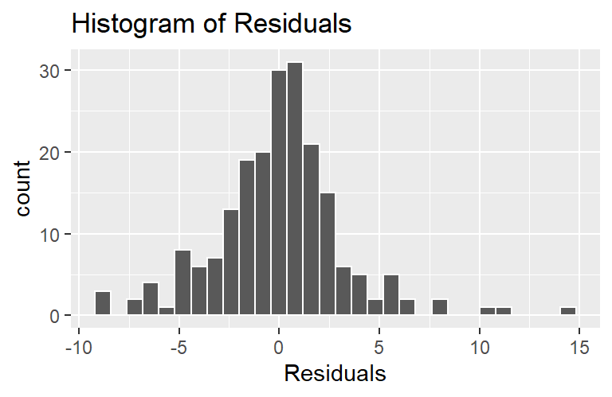

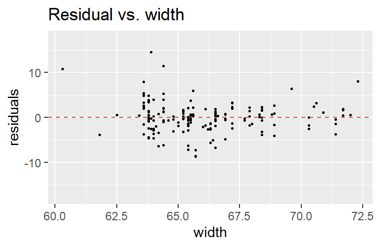

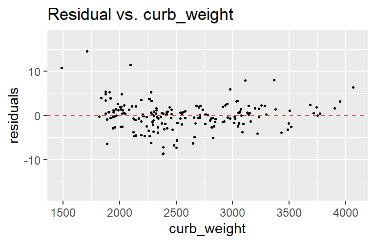

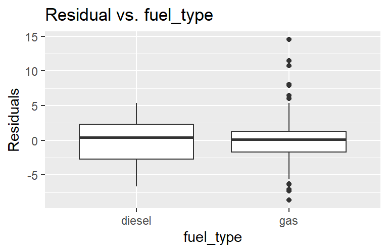

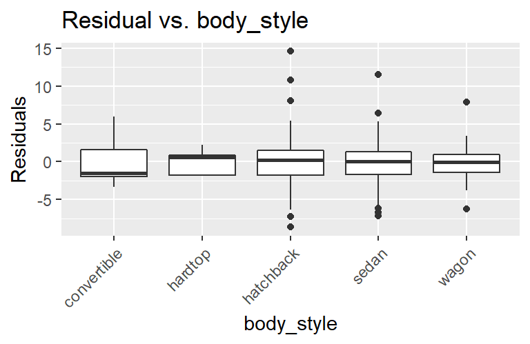

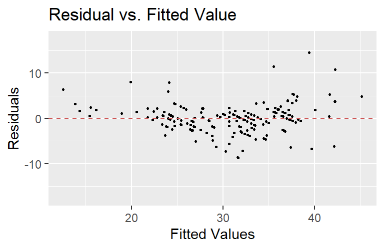

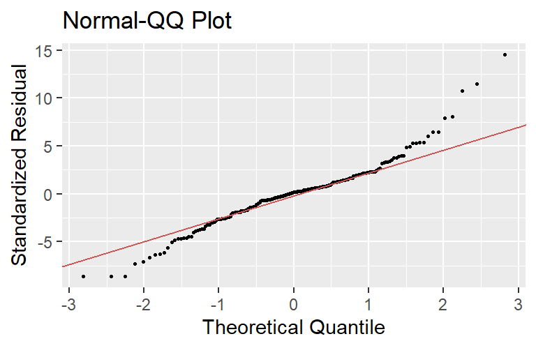

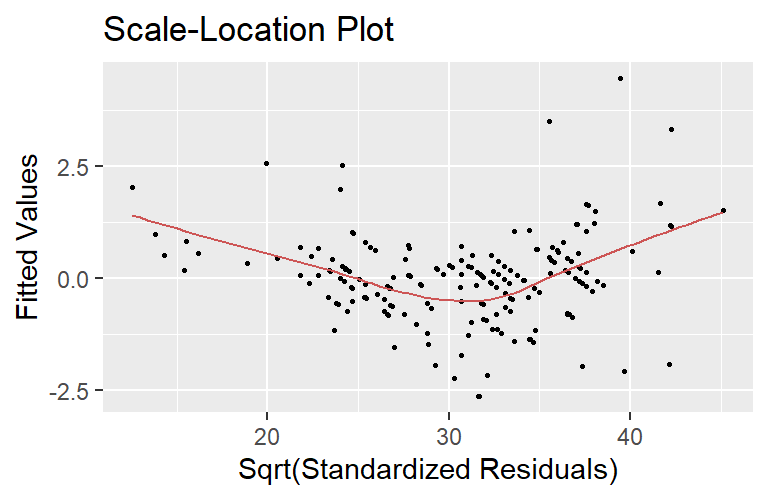

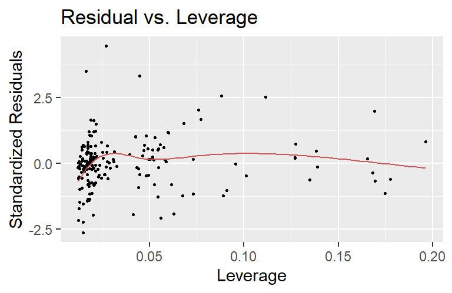

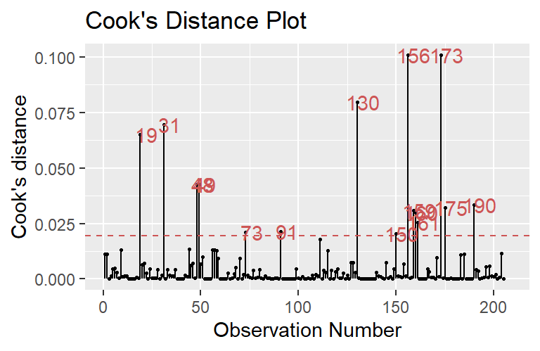

```r
linmod4 %>%
  gg_diagnose(max.per.page = 1)
```

First consider the histogram and qq plot for the residuals. These are not perfect, but okay.

Now look the scatter against the covariates, width and curb_weight, and the plot of fitted against residuals. These again look *okay*, maybe a bit more spread at lower widths, and a slight u shape to the residuals vs weight and fitted versus residuals. We could transform, but there isn’t a clear physical reason to do this, and it is likely that actually these effects are due to important missing predictors that may be correlated to curb weight. If the main point of this subsection were to develop a good model, I would look into this more, but for the current purposes, it is fine.

Next consider the residuals versus the categorical variables: The interquartile ranges in the boxplots look pretty similar, so the model seems fine, if not optimised.

The final model is (with coefficients rounded here to 2$\sigma$ for compactness):

$$\begin{align}
\mbox{mean highway mpg} \sim N( &71 + -0.064\times {\rm width} \\
&- 0.011\times{\rm curb-weight} -
8.7\times {\rm isgas} \\
&+ 0.33\times {\rm ishardtop} + 0.82\times {\rm ishatchback} + 1.3\times {\rm issedan} \\ & + 1.5\times {\rm iswagon}, 3.3).
\end{align}$$

## 4.3 Predicting with factors

Now we can answer summarising questions for the cars in this dataset, such as:

- How many fewer mpg does a car get on average for each additional pound of curb weight? For each additional inch of width?
- All other variables being equal, how many more mpg did wagons get on average than hatchbacks?
- What is the benefit in mpg to diesel over gas (petrol)?

Note that which predictor variables are the variables of interest and which are confounding variables depends on the question you are asking. The variables named in the question are the ones of interest. The ones that aren’t are the confounders (all other variables being equal) for which you are controlling.

For instance, probably in general wagons get much LOWER mpg than hatchbacks, but that is because they generally weigh more. Once we have controlled for differences in weight by including weight as a predictor in the model, we can see that *for cars of the same weight, width and with the same fuel type*, on average wagons got better mpg than hatchbacks.

# 4.4 Exercises

1. Answer the questions in the previous section using the model we built.
2. In a separate notebook, build a model of horsepower as a function of engine type, engine size and stroke. Invent some questions and answer them using your model.